# Week 7 / Lab 04: Reading and importing data

AG Schissler (modified from Ryan Tibshirani)

Monday October 8, 2018

## I. Opening

### Start-of-class work

1. Log in the your workstation.
2. Open the RStudio application on your machine.
3. Open lesson12_importing_data.Rmd from website so that you can work along the lecture.
4. Open lab_04_reading_cleaning_data.Rmd to have the lab available for review.

### This week’s agenda

- Importing data
- Learning from the assessment

## II. Midterm 1 feedback

- Exam Analysis: summary scores

```r
eval_data <- read.table("/Users/alfred/OneDrive - University of Nevada, Reno/Teaching/STAT_445-645/git_private/tests/Midterm1-2018-10-03/nops_eval.csv", sep=";", quote="", header=T,stringsAsFactors = F)

## remove names
eval_data <- eval_data[,-(1:3)]
str(eval_data[,2:8])
```

```
## 'data.frame':    18 obs. of  7 variables:
##  $ scrambling: int  0 0 0 0 0 0 0 0 0 0 ...
##  $ scan      : chr  "doc08482720181004144134_Page_01.png" "doc08482720181004144134_Page_02.png" "doc08482720181004144134_Page_03.png" "doc08482720181004144134_Page_04.png" ...
##  $ points    : int  70 75 70 75 85 75 80 80 65 40 ...
##  $ mark      : int  3 2 3 2 1 2 2 2 3 5 ...
##  $ answer.1  : int  11100 11000 10000 11010 11010 11010 11010 11010 11000 11010 ...
##  $ solution.1: int  11100 11010 11010 11010 11010 11010 11010 11010 11010 11010 ...
##  $ check.1   : int  1 0 0 1 1 1 1 1 0 1 ...
```

```r
summary(eval_data[, "points"])
```

```
##    Min. 1st Qu.  Median    Mean 3rd Qu.    Max.
##   40.00   66.25   75.00   70.83   80.00   95.00
```

- Question analysis Scatterplots

```r
###########################################################
## Correlate individual question scores with rest of the exam

check_data <- eval_data[,grep("check", names(eval_data))]
str(check_data)
```

```
## 'data.frame':    18 obs. of  20 variables:
##  $ check.1 : int  1 0 0 1 1 1 1 1 0 1 ...
##  $ check.2 : int  1 1 1 1 1 1 1 1 1 0 ...
##  $ check.3 : int  1 1 1 0 1 0 1 1 0 0 ...
##  $ check.4 : int  0 1 0 1 1 1 0 1 0 0 ...
##  $ check.5 : int  1 1 0 1 1 1 1 1 1 0 ...
##  $ check.6 : int  1 1 1 1 1 1 1 1 1 1 ...
##  $ check.7 : int  1 0 0 0 1 1 0 0 0 0 ...
##  $ check.8 : int  1 1 1 1 0 1 1 1 1 0 ...
##  $ check.9 : int  1 1 1 1 1 1 1 1 1 0 ...
##  $ check.10: int  1 1 1 1 1 1 1 1 1 1 ...
##  $ check.11: int  0 0 0 1 0 0 0 0 0 0 ...
##  $ check.12: int  0 0 0 0 0 1 0 0 1 1 ...
##  $ check.13: int  0 1 1 1 1 0 1 1 0 0 ...
##  $ check.14: int  0 0 1 0 1 0 1 1 1 0 ...
##  $ check.15: int  1 1 1 1 1 0 1 1 1 1 ...
##  $ check.16: int  1 1 1 1 1 1 1 1 1 1 ...
##  $ check.17: int  1 1 1 1 1 1 1 1 1 1 ...
##  $ check.18: int  1 1 1 1 1 1 1 1 1 1 ...
##  $ check.19: int  0 1 1 0 1 1 1 0 1 0 ...
##  $ check.20: int  1 1 1 1 1 1 1 1 0 0 ...
```

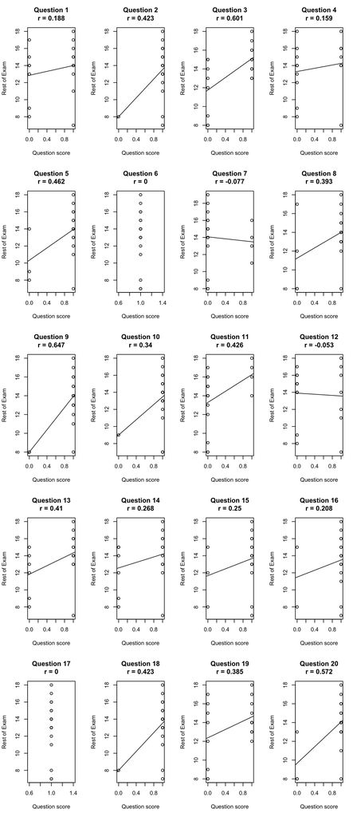

```r
cor_values <- NULL
par(mfrow = c(5,4))
for (j in 1:ncol(check_data)) {
    tmp_question = check_data[, j]
    tmp_rest = rowSums(check_data[, -j])
    if (var(tmp_question) > 0) {
        tmp_cor = round(cor(tmp_rest, tmp_question), 3)
    } else tmp_cor = 0
    cor_values <- c(cor_values, tmp_cor)
    plot(tmp_question, tmp_rest, main=paste0("Question ",j,"\nr = ",tmp_cor),
         xlab = "Question score", ylab = "Rest of Exam")
    if (tmp_cor != 0) {abline(lm(tmp_rest ~ tmp_question))}
    ## text(x = (max(tmp_question) - min(tmp_question))/2, y = max(tmp_rest) - sd(tmp_rest), round(cor(tmp_rest, tmp_question), 2))
}
```

```r
new_denom <- 18
eval_data$adj_points <- round( 100 * (eval_data[, "points"]/5) / new_denom, 0)

summary(eval_data$adj_points)
```

```
##    Min. 1st Qu.  Median    Mean 3rd Qu.    Max.
##   44.00   73.50   83.00   78.61   89.00  106.00
```

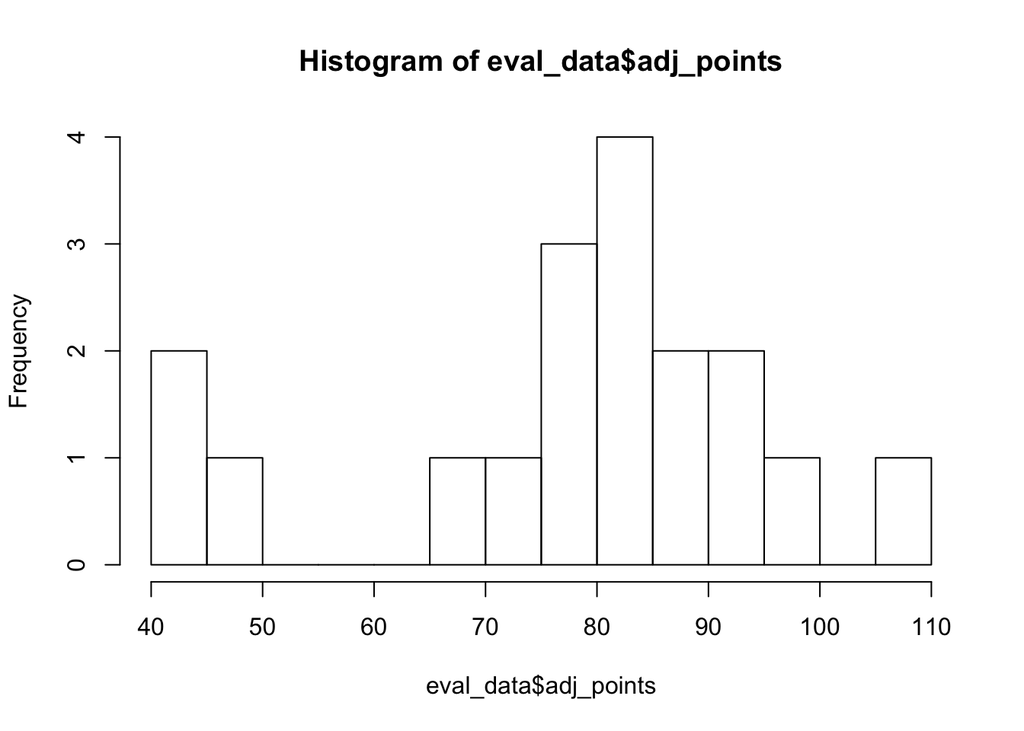

```r
hist(eval_data$adj_points, breaks = 10)
```

```r
letter_grade <- cut(eval_data$adj_points, c(0, 60, 70, 80, 90, Inf), right=FALSE, labels=c("F", LETTERS[4:1]))
table(letter_grade)
```

```
## letter_grade
## F D C B A
## 3 1 4 6 4
```

- Discuss the PCA.
- I’ll email your score report soon. Please check that your report was properly scanned.
- Offer: Replace Midterm 1 with your final exam test grade.

## III. Reading/writing data

All along, we’ve already been reading in data from the outside, using:

- `readLines()`: reading in lines of text from a file or webpage; returns vector of strings
- `read.table()`: read in a data table from a file or webpage; returns data frame
- `read.csv()`: like the above, but assumes comma separated data; returns data frame

This week we’ll focus on `read.table()`, `read.csv()` and their counterparts `write.table()`, `write.csv()`, respectively.

#### Reading in data from a previous R session

- `readRDS()`, `saveRDS()`: functions for reading/writing single R objects from/to a file
- `load()`, `save()`: functions for reading/writing any number of R objects from/to a file

Advantage: these can be a lot more memory efficient than what we’ll cover this week. Disadvantage: they’re limited in scope in the sense that they can only communicate with R.

#### `read.table()`, `read.csv()`

Have a table full of data, just not in the R file format? Then `read.table()` is the function for you. It works as in:

- `read.table(file=file_name, sep=" ")`, to read data from a local file on your computer called `file_name`, assuming (say) space separated data
- `read.table(file=webpage_link, sep="\t")`, to read data from a webpage up at `webpage_link`, assuming (say) tab separated data

The function `read.csv()` is just a shortcut for using `read.table()` with `sep=","`. (But note: these two actually differ on some of the default inputs!)

#### Helpful input arguments

The following inputs apply to either `read.table()` or `read.csv()` (though these two functions actually have different default inputs in general—e.g., `header` defaults to TRUE in `read.csv()` but FALSE in `read.table()`)

- `header`: boolean, TRUE is the first line should be interpreted as column names
- `sep`: string, specifies what separates the entries; empty string “” is interpreted to mean any white space
- `quote`: string, specifies what set of characters signify the beginning and end of quotes; empty string “” disables quotes altogether

Other helpful inputs: `skip`, `row.names`, `col.names`. You can read about them in the help file for `read.table()` .

# Another example of reading in data

```r
# This data table is tab separated, and it comes with column names
sprint_df <- read.table(
  file="http://www.stat.cmu.edu/~ryantibs/statcomp/data/sprint.m.dat",
  sep="\t", header=TRUE)
```

```
## Error in scan(file = file, what = what, sep = sep, quote = quote, dec = dec, : line 981 did not have 8 elements
```

```r
# Oops! It turns out it has some apostrophe marks in the City column,
# so we have to set quote=""
sprint_df <- read.table(
  file="http://www.stat.cmu.edu/~ryantibs/statcomp/data/sprint.m.dat",
  sep="\t", header=TRUE, quote="")
head(sprint_df)
```

```
##   Rank Time Wind        Name Country Birthdate     City       Date
## 1    1 9.58  0.9  Usain Bolt     JAM  21.08.86   Berlin 16.08.2009
## 2    2 9.63  1.5  Usain Bolt     JAM  21.08.86   London 05.08.2012
## 3    3 9.69  0.0  Usain Bolt     JAM  21.08.86  Beijing 16.08.2008
## 4    3 9.69  2.0   Tyson Gay     USA  09.08.82 Shanghai 20.09.2009
## 5    3 9.69 -0.1 Yohan Blake     JAM  26.12.89 Lausanne 23.08.2012
## 6    6 9.71  0.9   Tyson Gay     USA  09.08.82   Berlin 16.08.2009
```

```r
sapply(sprint_df, class)
```

```
##      Rank      Time      Wind      Name   Country Birthdate      City
## "integer" "numeric" "numeric"  "factor"  "factor"  "factor"  "factor"
##      Date
##  "factor"
```

```r
unique(grep("'", sprint_df$City, value=TRUE)) # This is the troublemaker
```

```
## [1] "Villeneuve d'Ascq"
```

#### `write.table()`, `write.csv()`

To write a data frame (or matrix) to a text file, use `write.table()` or `write.csv()`. These are the counterparts to `read.table()` and `read.csv()`, and they work as in:

- `write.table(my_df, file="my_df.txt", sep=" ", quote=FALSE)`, to write `my_dat` to the text file “my_df_txt” (to be created in your working directory), with (say) space separation, and no quotes around the entries
- `write.csv(my_df, file="my_df_csv", quote=FALSE)`, to write `my_dat` to the text file “my_df.csv” (to be created in your working directory), with comma separation, and no quotes.

Note that `quote=FALSE`, signifying that no quotes should be put around the printed data entries, seems always preferable (default is `quote=TRUE`). Also, setting `row.names=FALSE` and `col.names=FALSE` will disable the printing of row and column names (defaults are `row.names=TRUE` and `col.names=TRUE`).

## IV. Lab 04

- Example responses in Lab 04.
- Hand back lab rubrics

## V. Summary

3 new R functions 2 stats ideas 1 action item for you to do.